# CAiP3第14章推移と回帰の関係

/Users/kazuo/Dropbox/RStudio/CAiP3/CAiP3-Chap14-trans-regress.Rmd

fujimoto@sakushin-u.ac.jp

2020年 4月 8日 水曜日 07時12分50秒 JST

# 1 科学資金データを読み込む -> funding.df

```r
.d <- read_excel(path="funding.xls")
.d %>% column_to_rownames("...1") -> funding.df
knitr::kable(funding.df)
```

|  | A | B | C | D | E |
| --- | --- | --- | --- | --- | --- |
| Geol | 3 | 19 | 39 | 14 | 10 |
| Bioc | 1 | 2 | 13 | 1 | 12 |
| Chem | 6 | 25 | 49 | 21 | 29 |
| Zool | 3 | 15 | 41 | 35 | 26 |
| Phys | 10 | 22 | 47 | 9 | 26 |
| Engi | 3 | 11 | 25 | 15 | 34 |
| Micr | 1 | 6 | 14 | 5 | 11 |
| Bota | 0 | 12 | 34 | 17 | 23 |
| Stat | 2 | 5 | 11 | 4 | 7 |
| Math | 2 | 11 | 37 | 8 | 20 |

# 2 rowcoord, colcoord をcaから取得し、fundingデータを標準座標で数量化する

```r
res.ca <- ca(funding.df)

y <- res.ca$rowcoord[,1] # 行標準座標 Dim 1
x <- res.ca$colcoord[,1] # 列標準座標 Dim 1
#res.ca$N
.d %>% rename(disp = "...1") %>% gather(key="CAT",valu=NN,-disp) %>%
  mutate(CAT.n = recode(CAT,!!!x)) %>% mutate(disp.n = recode(disp,!!!y)) -> .dd
.dd %>% head() %>% knitr::kable()
```

| disp | CAT | NN | CAT.n | disp.n |
| --- | --- | --- | --- | --- |
| Geol | A | 3 | 2.417466 | 0.3862961 |
| Bioc | A | 1 | 2.417466 | 0.9095585 |
| Chem | A | 6 | 2.417466 | 0.1903353 |
| Zool | A | 3 | 2.417466 | -1.6552083 |
| Phys | A | 10 | 2.417466 | 1.5954790 |
| Engi | A | 3 | 2.417466 | -0.5940710 |

```r
.dd %>% tail() %>% knitr::kable()
```

| disp | CAT | NN | CAT.n | disp.n |
| --- | --- | --- | --- | --- |
| Phys | E | 26 | -0.1613446 | 1.5954790 |
| Engi | E | 34 | -0.1613446 | -0.5940710 |
| Micr | E | 11 | -0.1613446 | 0.0645485 |
| Bota | E | 23 | -0.1613446 | -0.9035071 |
| Stat | E | 7 | -0.1613446 | 0.6301904 |
| Math | E | 20 | -0.1613446 | 0.5397496 |

# 3 Exhibit14.2 の再描画

## 3.1 CAT, disp でグループ化して加重平均を求めた後、lmを行う。

- 加重平均は、weighted.mean で計算する。加重平均の考え方は、付録のステップ計算を参照。
- group_by %>% summarize の使い方は、RDS3.6 参照
- lm のresultの解釈については、金名哲『Rによるデータサイエンス（第2版）』2017、森北出版の第11章線形回帰分析（p133）を参照。特にp136から解析結果の読み方がある。

```r
#.dd %>% group_by(CAT)%>% summarise(wmean=weighted.mean(x=disp.n,w=NN)) -> CAT.wmean
.dd %>% group_by(CAT)%>% summarise(wmean=weighted.mean(x=disp.n,w=NN)) %>% mutate(CAT.val=x) %>%
  lm(wmean ~ CAT.val,.) -> CAT.val.model
CAT.val.model
```

```
##
## Call:
## lm(formula = wmean ~ CAT.val, data = .)
##
## Coefficients:
## (Intercept)      CAT.val
##  -1.055e-16    1.978e-01
```

```r
.dd %>% group_by(disp)%>% summarise(wmean=weighted.mean(x=CAT.n,w=NN)) %>% # disp をsortしてmutate
 mutate(disp.val=unlist((data.frame(names(y),y) %>% arrange(names.y.) %>% select(y)))) %>%
  lm(disp.val ~ wmean ,.)  -> disp.val.model
disp.val.model
```

```
##
## Call:
## lm(formula = disp.val ~ wmean, data = .)
##
## Coefficients:
## (Intercept)        wmean
##  -7.373e-16    5.056e+00
```

## 3.2 加重平均した値をmutateしてグラフ描画用のデータを作成する .dd2

- CAT.wmean 資金カテゴリの加重平均
- disp.wmean 研究分野の加重平均
- ggplot で図の重ね合わせをやるためにデータを拡張する。（.dd2）

```r
## setNames でmutateで使う変換表をつくる。
## CAT.wmean ---- 資金カテゴリの加重平均
## disp.wmean --- 学問分野の加重平均

.dd %>% group_by(CAT)%>% summarise(wmean=weighted.mean(x=disp.n,w=NN)) -> CAT.wmean
CAT.wmean
```

```
## # A tibble: 5 x 2
##   CAT     wmean
##   <chr>   <dbl>
## 1 A      0.478
## 2 B      0.127
## 3 C      0.0825
## 4 D     -0.390
## 5 E     -0.0319
```

```r
setNames(CAT.wmean$wmean,CAT.wmean$CAT) -> setCAT
setCAT["A"] # 動作確認
```

```
##         A
## 0.4781239
```

```r
.dd %>% group_by(disp)%>% summarise(wmean=weighted.mean(x=CAT.n,w=NN)) -> disp.wmean
disp.wmean
```

```
## # A tibble: 10 x 2
##    disp    wmean
##    <chr>   <dbl>
##  1 Bioc   0.180
##  2 Bota  -0.179
##  3 Chem   0.0376
##  4 Engi  -0.117
##  5 Geol   0.0764
##  6 Math   0.107
##  7 Micr   0.0128
##  8 Phys   0.316
##  9 Stat   0.125
## 10 Zool  -0.327
```

```r
setNames(disp.wmean$wmean,disp.wmean$disp) -> setdisp

.dd %>% mutate(CAT.wm = setCAT[CAT],disp.wm = setdisp[disp]) -> .dd2
.dd2 %>% head() %>% knitr::kable()
```

| disp | CAT | NN | CAT.n | disp.n | CAT.wm | disp.wm |
| --- | --- | --- | --- | --- | --- | --- |
| Geol | A | 3 | 2.417466 | 0.3862961 | 0.4781239 | 0.0764013 |
| Bioc | A | 1 | 2.417466 | 0.9095585 | 0.4781239 | 0.1798915 |
| Chem | A | 6 | 2.417466 | 0.1903353 | 0.4781239 | 0.0376443 |
| Zool | A | 3 | 2.417466 | -1.6552083 | 0.4781239 | -0.3273654 |
| Phys | A | 10 | 2.417466 | 1.5954790 | 0.4781239 | 0.3155522 |
| Engi | A | 3 | 2.417466 | -0.5940710 | 0.4781239 | -0.1174947 |

```r
.dd2 %>% tail() %>% knitr::kable()
```

| disp | CAT | NN | CAT.n | disp.n | CAT.wm | disp.wm |
| --- | --- | --- | --- | --- | --- | --- |
| Phys | E | 26 | -0.1613446 | 1.5954790 | -0.0319106 | 0.3155522 |
| Engi | E | 34 | -0.1613446 | -0.5940710 | -0.0319106 | -0.1174947 |
| Micr | E | 11 | -0.1613446 | 0.0645485 | -0.0319106 | 0.0127663 |
| Bota | E | 23 | -0.1613446 | -0.9035071 | -0.0319106 | -0.1786947 |
| Stat | E | 7 | -0.1613446 | 0.6301904 | -0.0319106 | 0.1246384 |
| Math | E | 20 | -0.1613446 | 0.5397496 | -0.0319106 | 0.1067511 |

## 3.3 Exhibit 14.2 を描く

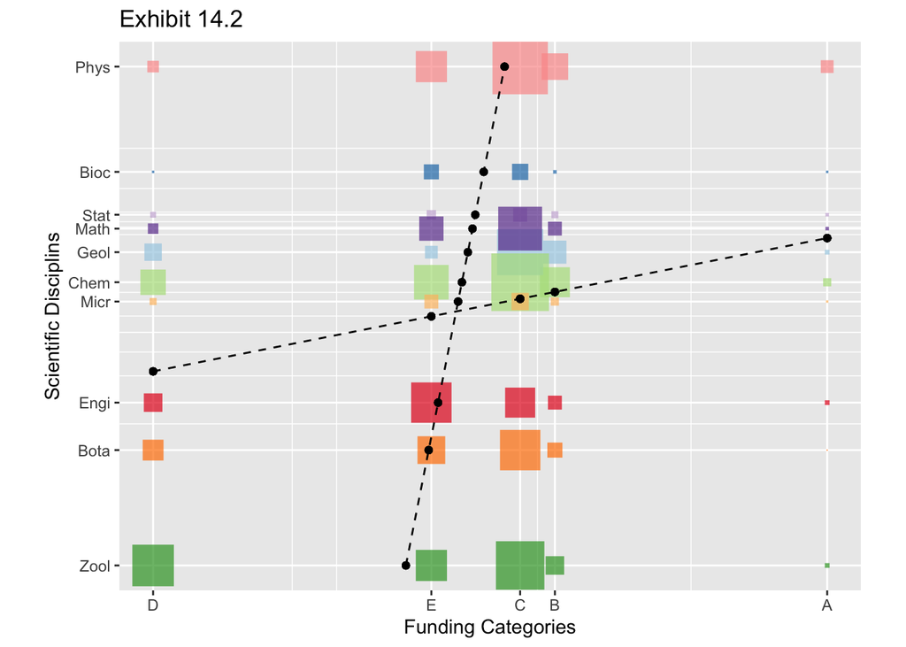

```r
cols  <- brewer.pal(10, "Paired")# Set3

.dd2 %>% ggplot() +
  geom_point(aes(x=CAT.n,y=disp.n),size=.dd$NN*0.3,colour=rep(cols,5),alpha=0.7,shape=15) -> p
p <- p + ggtitle("Exhibit 14.2") + ylim(range(y)*1.2) + coord_fixed(ratio = 1)
p <- p + ylab("Scientific Disciplins") + xlab("Funding Categories")
p <- p + scale_y_continuous(breaks = y,labels=names(y)) +
  scale_x_continuous(breaks = x,labels=names(x)) + coord_fixed(ratio = 1)
p <- p + geom_point(aes(x=CAT.n,y=CAT.wm)) +  # 資金カテゴリの加重平均位置
  geom_line(aes(x=CAT.n,y=CAT.wm),linetype="dashed")
p <- p + geom_point(aes(x=disp.wm,y=disp.n)) +  # 研究分野の加重平均位置
  geom_line(aes(x=disp.wm,y=disp.n),linetype="dashed")
p
```

# 4 重回帰分析を行う

y = 行主座標(10) fundings.df(10x5)

```r
#応答変数= 行prin
#係数行列 funding.df
res.ca$sv[1] # Dα 特異値= √λ
```

```
## [1] 0.197779
```

```r
res.ca$rowcoord[,1] #  row std coord (Dim1)
```

```
##        Geol        Bioc        Chem        Zool        Phys        Engi
##  0.38629613  0.90955851  0.19033533 -1.65520832  1.59547904 -0.59407096
##        Micr        Bota        Stat        Math
##  0.06454846 -0.90350715  0.63019040  0.53974964
```

```r
res.ca$rowcoord[,1] * res.ca$sv[1] -> rowcoord.prin
rowcoord.prin
```

```
##        Geol        Bioc        Chem        Zool        Phys        Engi
##  0.07640125  0.17989155  0.03764433 -0.32736540  0.31555220 -0.11749474
##        Micr        Bota        Stat        Math
##  0.01276633 -0.17869471  0.12463841  0.10675113
```

```r
#0.076 / 0.38629613
#str(res.ca)

#funding.df %>% sum() -> NN
#funding.df /NN -> funding.p
cbind(rowprin=rowcoord.prin,funding.df) -> .dd3
.dd3
```

```
##          rowprin  A  B  C  D  E
## Geol  0.07640125  3 19 39 14 10
## Bioc  0.17989155  1  2 13  1 12
## Chem  0.03764433  6 25 49 21 29
## Zool -0.32736540  3 15 41 35 26
## Phys  0.31555220 10 22 47  9 26
## Engi -0.11749474  3 11 25 15 34
## Micr  0.01276633  1  6 14  5 11
## Bota -0.17869471  0 12 34 17 23
## Stat  0.12463841  2  5 11  4  7
## Math  0.10675113  2 11 37  8 20
```

```r
lm(rowprin ~ A+B+C+D+E,.dd3)
```

```
##
## Call:
## lm(formula = rowprin ~ A + B + C + D + E, data = .dd3)
##
## Coefficients:
## (Intercept)            A            B            C            D            E
##    0.110640     0.034413    -0.003661     0.005412    -0.016280    -0.005313
```

```r
lm(rowprin ~ -1 + A+B+C+D+E,.dd3)
```

```
##
## Call:
## lm(formula = rowprin ~ -1 + A + B + C + D + E, data = .dd3)
##
## Coefficients:
##         A          B          C          D          E
##  0.030367  -0.006524   0.009198  -0.017952  -0.002717
```

```r
cbind(rowprin=res.ca$rowcoord[,1] ,funding.df) -> .dd4
.dd4
```

```
##          rowprin  A  B  C  D  E
## Geol  0.38629613  3 19 39 14 10
## Bioc  0.90955851  1  2 13  1 12
## Chem  0.19033533  6 25 49 21 29
## Zool -1.65520832  3 15 41 35 26
## Phys  1.59547904 10 22 47  9 26
## Engi -0.59407096  3 11 25 15 34
## Micr  0.06454846  1  6 14  5 11
## Bota -0.90350715  0 12 34 17 23
## Stat  0.63019040  2  5 11  4  7
## Math  0.53974964  2 11 37  8 20
```

```r
lm(rowprin ~ A+B+C+D+E,.dd4)
```

```
##
## Call:
## lm(formula = rowprin ~ A + B + C + D + E, data = .dd4)
##
## Coefficients:
## (Intercept)            A            B            C            D            E
##     0.55941      0.17400     -0.01851      0.02736     -0.08232     -0.02686
```

# 5 付録：

## 5.1 特異値分解SVDで慣性（固有値）、標準座標、主座標をもとめる。

- $\mathbf P = \frac{1}{n}\mathbf N$

CA Step 1 — 標準残差行列Sを計算する Calculate the matrix /$\bf S$ of standarized residuals:

- $\mathbf{S} = \mathbf{D}_r^{-\mkern-2mu \frac{1}{2}}(\mathbf{P}-\mathbf{rc}^t)\mathbf{D}_c^{-\mkern-2mu \frac{1}{2}}$

CA Step 2 — SのSVDを計算する Calculate the SVD of $\bf S$

- $\mathbf{S} = \mathbf{U}\mathbf{D}_\alpha\mathbf{V}^t$

ここで

- $\mathbf{U}^t \mathbf{U} = \mathbf{V}^t \mathbf{V} = \mathbf{I}$

CA Step 3 — 行の標準座標 Standard coordinates /$\bf\Phi$ of rows:

- $\mathbf{\Phi} = \mathbf{D}_r^{-\mkern-2mu \frac{1}{2}}\mathbf{U}$

CA Step 4 — 列の標準座標 Standard coordinates /$\bf\Gamma$ of columns:

- $\mathbf{\Gamma} = \mathbf{D}_c^{-\mkern-2mu \frac{1}{2}}\mathbf{V}$

CA Step 5 — 行の主座標 Principal coordinates $\bf F$ of rows:

- $\mathbf{F} = \mathbf{D}_r^{-\mkern-2mu \frac{1}{2}}\mathbf{U}\mathbf{D}_\alpha = {\bf \Phi}\mathbf{D}_\alpha$

CA Step 6 — 列の主座標 Principal coordinates $\bf G$ of columns:

- $\mathbf{G} = \mathbf{D}_c^{-\mkern-2mu \frac{1}{2}}\mathbf{V}\mathbf{D}_\alpha = {\bf \Gamma}\mathbf{D}_\alpha$

CA Step 7 — 主慣性 Principal inertias $\lambda_k$:

- $\lambda_k = \alpha_k^2,\quad k=1,2,\ldots,K {\rm \ ここで\ } K = {\rm min}\{I-1,J-1\}$

```r
sum(funding.df) -> N
P <- as.matrix(funding.df / N)
r <- apply(P,1,sum)
c <- apply(P,2,sum)
S <- diag(1/sqrt(r)) %*% (P - r %*% t(c)) %*% diag(1/sqrt(c))
SVD <- svd(S)
SVD$d # 特異値
```

```
## [1] 1.977790e-01 1.743009e-01 1.042556e-01 5.012199e-02 6.638530e-17
```

```r
SVD$u #
```

```
##              [,1]        [,2]        [,3]       [,4]        [,5]
##  [1,]  0.12623311  0.56725489  0.27503963 -0.2276201 -0.03954909
##  [2,]  0.17360935 -0.49825378  0.27776286  0.3691305  0.49326424
##  [3,]  0.07691916  0.17007309 -0.16424115 -0.3575275  0.26914063
##  [4,] -0.64266811  0.22784434 -0.24026640  0.5379930 -0.15341738
##  [5,]  0.60379150  0.05861454 -0.39452905  0.2494107 -0.38321588
##  [6,] -0.19752548 -0.55646706 -0.34229832 -0.3771648 -0.34060711
##  [7,]  0.01391651 -0.13563699  0.08568729 -0.2727124 -0.14892045
##  [8,] -0.29697800 -0.07260543  0.40688092 -0.2084254 -0.08560510
##  [9,]  0.12028577  0.01550838 -0.19624345  0.1096824  0.26965321
## [10,]  0.16895970 -0.11012016  0.52751369  0.2456967 -0.54227916
```

```r
SVD$v #
```

```
##             [,1]        [,2]       [,3]       [,4]      [,5]
## [1,]  0.47707276  0.08183444 -0.7398624  0.4235134 0.1973442
## [2,]  0.25800640  0.39890356 -0.1251502 -0.7732025 0.4010038
## [3,]  0.26032157  0.17838093  0.5872988  0.4074872 0.6240571
## [4,] -0.79472740  0.32170520 -0.2807602  0.1550082 0.4025671
## [5,] -0.08046934 -0.83598151 -0.1148688 -0.1808896 0.4987421
```

```r
SVD$d^2 #固有値
```

```
## [1] 3.911652e-02 3.038081e-02 1.086924e-02 2.512214e-03 4.407008e-33
```

```r
r.std <- diag(1/sqrt(r)) %*% SVD$u
r.std # 行標準座標
```

```
##              [,1]       [,2]       [,3]       [,4]       [,5]
##  [1,]  0.38629613  1.7359025  0.8416710 -0.6965587 -0.1210273
##  [2,]  0.90955851 -2.6104065  1.4552302  1.9339155  2.5842657
##  [3,]  0.19033533  0.4208433 -0.4064123 -0.8846966  0.6659845
##  [4,] -1.65520832  0.5868190 -0.6188123  1.3856150 -0.3951304
##  [5,]  1.59547904  0.1548850 -1.0425169  0.6590513 -1.0126226
##  [6,] -0.59407096 -1.6736115 -1.0294849 -1.1343482 -1.0243984
##  [7,]  0.06454846 -0.6291205  0.3974404 -1.2649127 -0.6907327
##  [8,] -0.90350715 -0.2208902  1.2378688 -0.6341004 -0.2604396
##  [9,]  0.63019040  0.0812501 -1.0281411  0.5746380  1.4127429
## [10,]  0.53974964 -0.3517840  1.6851671  0.7848895 -1.7323361
```

```r
r.prin <- r.std %*% diag(SVD$d)
r.prin # 行主座標
```

```
##              [,1]        [,2]        [,3]        [,4]          [,5]
##  [1,]  0.07640125  0.30256937  0.08774894 -0.03491291 -8.034437e-18
##  [2,]  0.17989155 -0.45499621  0.15171595  0.09693169  1.715573e-16
##  [3,]  0.03764433  0.07335338 -0.04237077 -0.04434275  4.421158e-17
##  [4,] -0.32736540  0.10228308 -0.06451467  0.06944978 -2.623085e-17
##  [5,]  0.31555220  0.02699660 -0.10868826  0.03303296 -6.722325e-17
##  [6,] -0.11749474 -0.29171201 -0.10732960 -0.05685579 -6.800500e-17
##  [7,]  0.01276633 -0.10965627  0.04143541 -0.06339994 -4.585450e-17
##  [8,] -0.17869471 -0.03850136  0.12905480 -0.03178237 -1.728936e-17
##  [9,]  0.12463841  0.01416197 -0.10718950  0.02880200  9.378536e-17
## [10,]  0.10675113 -0.06131627  0.17568817  0.03934022 -1.150016e-16
```

```r
c.std <- diag(1/sqrt(c)) %*% SVD$v
c.std # 列標準座標
```

```
##            [,1]       [,2]       [,3]       [,4] [,5]
## [1,]  2.4174656  0.4146788 -3.7490968  2.1460648    1
## [2,]  0.6434014  0.9947626 -0.3120924 -1.9281676    1
## [3,]  0.4171438  0.2858407  0.9410979  0.6529646    1
## [4,] -1.9741487  0.7991343 -0.6974245  0.3850494    1
## [5,] -0.1613446 -1.6761798 -0.2303170 -0.3626916    1
```

```r
c.prin <- c.std %*% diag(SVD$d)
c.prin # 列主座標
```

```
##             [,1]        [,2]        [,3]        [,4]        [,5]
## [1,]  0.47812387  0.07227889 -0.39086446  0.10756503 6.63853e-17
## [2,]  0.12725128  0.17338803 -0.03253739 -0.09664359 6.63853e-17
## [3,]  0.08250228  0.04982230  0.09811476  0.03272788 6.63853e-17
## [4,] -0.39044510  0.13928983 -0.07271043  0.01929944 6.63853e-17
## [5,] -0.03191056 -0.29215966 -0.02401185 -0.01817882 6.63853e-17
```

```r
c.contr <- SVD$v
c.contr # 列寄与座標
```

```
##             [,1]        [,2]       [,3]       [,4]      [,5]
## [1,]  0.47707276  0.08183444 -0.7398624  0.4235134 0.1973442
## [2,]  0.25800640  0.39890356 -0.1251502 -0.7732025 0.4010038
## [3,]  0.26032157  0.17838093  0.5872988  0.4074872 0.6240571
## [4,] -0.79472740  0.32170520 -0.2807602  0.1550082 0.4025671
## [5,] -0.08046934 -0.83598151 -0.1148688 -0.1808896 0.4987421
```

## 5.2 Fundingカテゴリごとの加重平均計算の確認

- function としては、weight_mean を使えばいいが、計算の考え方が正しいか確認する。

### 5.2.1 ステップ計算で検算

```r
.dd %>% filter(CAT=="A") -> .dd.A
.dd.A$NN %>% sum() -> NNN
.dd.A %>% mutate(wmean.0 =NN * disp.n) %>% select(wmean.0) %>% unlist() %>% sum()/NNN # 加重平均
```

```
## [1] 0.4781239
```

### 5.2.2 資金カテゴリーごとの加重平均

```r
.dd %>% filter(CAT=="A") %>% weighted.mean(x=.$disp.n,w=.$NN) -> yA
yA
```

```
## [1] 0.4781239
```

```r
.dd %>% filter(CAT=="B") %>% weighted.mean(x=.$disp.n,w=.$NN) -> yB
yB
```

```
## [1] 0.1272513
```

```r
.dd %>% filter(CAT=="C") %>% weighted.mean(x=.$disp.n,w=.$NN) -> yC
yC
```

```
## [1] 0.08250228
```

```r
.dd %>% filter(CAT=="D") %>% weighted.mean(x=.$disp.n,w=.$NN) -> yD
yD
```

```
## [1] -0.3904451
```

```r
.dd %>% filter(CAT=="E") %>% weighted.mean(x=.$disp.n,w=.$NN) -> yE
yE
```

```
## [1] -0.03191056
```

### 5.2.3 plot してみる。

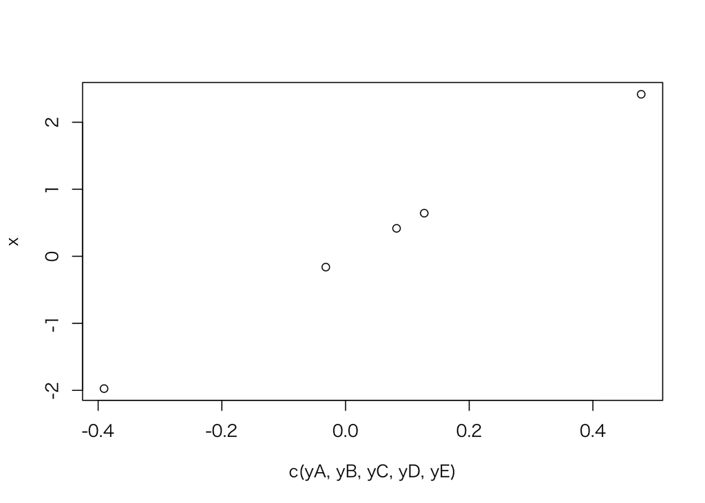

```r
plot(c(yA,yB,yC,yD,yE),x)
```

```r
.d.1 <- data.frame(y=c(yA,yB,yC,yD,yE),x)
lm(y ~ x, .d.1)
```

```
##
## Call:
## lm(formula = y ~ x, data = .d.1)
##
## Coefficients:
## (Intercept)            x
##  -1.055e-16    1.978e-01
```

```r
lm(c(yA,yB,yC,yD,yE) ~ x) # これでも同じ。
```

```
##
## Call:
## lm(formula = c(yA, yB, yC, yD, yE) ~ x)
##
## Coefficients:
## (Intercept)            x
##  -1.055e-16    1.978e-01
```

## 5.3 CAT, disp でグループ化して加重平均を求めた後、lmを行う。

- 加重平均は、weighted.mean で計算する。加重平均の考え方は、付録のステップ計算を参照。
- group_by %>% summarize の使い方は、RDS3.6 参照
- lm のresultの解釈については、金名哲『Rによるデータサイエンス（第2版）』2017、森北出版の第11章線形回帰分析（p133）を参照。特にp136から解析結果の読み方がある。

```r
#.dd %>% group_by(CAT)%>% summarise(wmean=weighted.mean(x=disp.n,w=NN)) -> CAT.wmean
.dd %>% group_by(CAT)%>% summarise(wmean=weighted.mean(x=disp.n,w=NN)) %>% mutate(CAT.val=x) %>%
  lm(wmean ~ CAT.val,.) -> CAT.val.model
summary(CAT.val.model)
```

```
##
## Call:
## lm(formula = wmean ~ CAT.val, data = .)
##
## Residuals:
##          1          2          3          4          5
##  4.164e-17 -1.056e-16  3.680e-17  2.410e-17  3.066e-18
##
## Coefficients:
##               Estimate Std. Error    t value Pr(>|t|)
## (Intercept) -1.055e-16  3.200e-17 -3.297e+00   0.0458 *
## CAT.val      1.978e-01  2.224e-17  8.893e+15   <2e-16 ***
## ---
## Signif. codes:  0 '***' 0.001 '**' 0.01 '*' 0.05 '.' 0.1 ' ' 1
##
## Residual standard error: 7.031e-17 on 3 degrees of freedom
## Multiple R-squared:      1,  Adjusted R-squared:      1
## F-statistic: 7.909e+31 on 1 and 3 DF,  p-value: < 2.2e-16
```

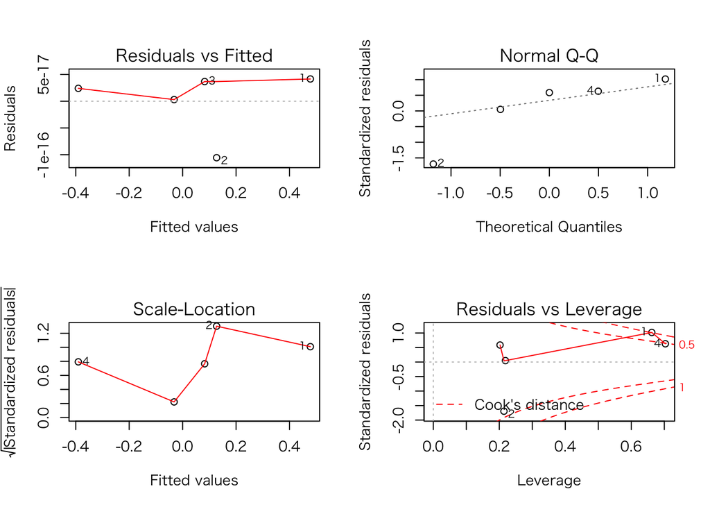

```r
oldpar <- par(mfrow=c(2,2))
CAT.val.model %>% plot()
```

```r
par(oldpar)

.dd %>% group_by(disp)%>% summarise(wmean=weighted.mean(x=CAT.n,w=NN)) %>% # disp をsortしてmutate
 mutate(disp.val=unlist((data.frame(names(y),y) %>% arrange(names.y.) %>% select(y)))) %>%
  lm(disp.val ~ wmean ,.)  -> disp.val.model
summary(disp.val.model)
```

```
##
## Call:
## lm(formula = disp.val ~ wmean, data = .)
##
## Residuals:
##        Min         1Q     Median         3Q        Max
## -7.834e-16 -1.878e-16 -5.302e-17  1.821e-16  1.100e-15
##
## Coefficients:
##               Estimate Std. Error    t value Pr(>|t|)
## (Intercept) -7.373e-16  1.667e-16 -4.423e+00  0.00222 **
## wmean        5.056e+00  9.331e-16  5.419e+15  < 2e-16 ***
## ---
## Signif. codes:  0 '***' 0.001 '**' 0.01 '*' 0.05 '.' 0.1 ' ' 1
##
## Residual standard error: 5.228e-16 on 8 degrees of freedom
## Multiple R-squared:      1,  Adjusted R-squared:      1
## F-statistic: 2.936e+31 on 1 and 8 DF,  p-value: < 2.2e-16
```

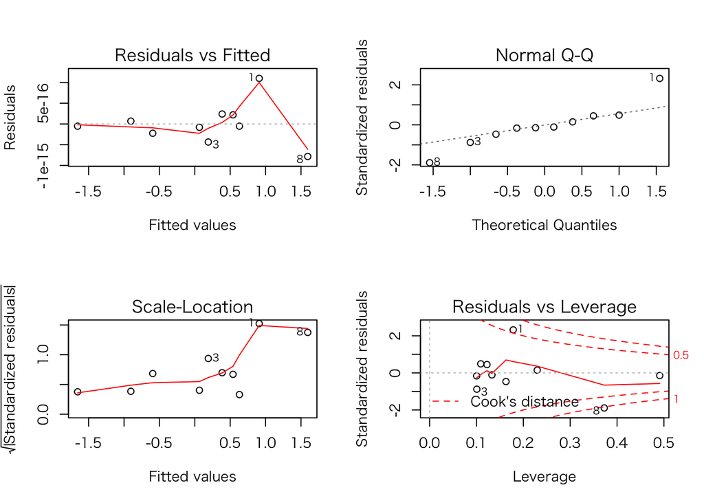

```r
oldpar <- par(mfrow=c(2,2))
disp.val.model %>% plot()
```

```r
par(oldpar)
```

# 6 xCAT の値が、p109 のCoefficient の値になっている。

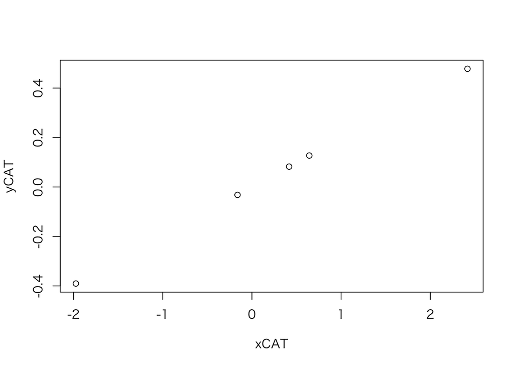

```r
#res.caは、caのresult
res.ca$colcoord[,1] *res.ca$sv[1] -> yCAT # 列主座標
res.ca$colcoord[,1] -> xCAT # 列標準座標
plot(xCAT,yCAT) # 直線にのるのあたり前...。ということは、この種「列座標」と「行標準座標」の関係がをどうよいとるのか、ということになるな。
```

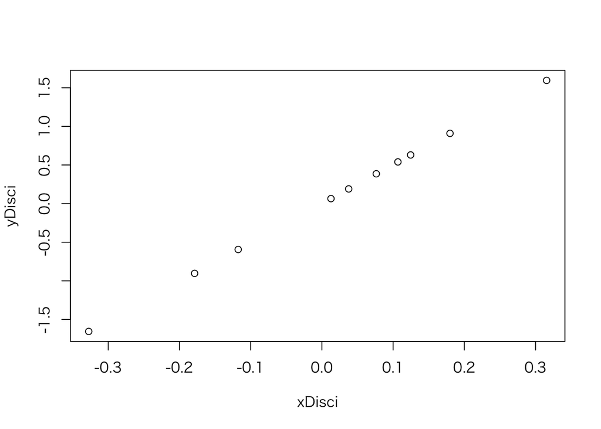

```r
res.ca$rowcoord[,1] *res.ca$sv[1] -> xDisci # 行主座標
res.ca$rowcoord[,1] -> yDisci # 行標準座標
plot(xDisci,yDisci)
```